# Relación del sedentarismo con problemas auditivos y visuales

Jorge Bermejo, Antonia Añazco, Daniel Marrón

2023-12-08

## INTRODUCCIÓN 📖

El sedentarismo representa un serio problema para la salud pública, especialmente en Occidente, según Rodulfo, J. I. A. (2019) 🤓 [1]. Algunos de sus principales efectos, ampliamente estudiados, se evidencian en trastornos como la hipertensión, la diabetes tipo II o la obesidad, las cuales ya alcanzan la categoría de epidemia en los Estados Unidos según Hu, F. B. (2003) 🤓 [2]. En el mismo artículo se habla también de la relación directa entre estos trastornos y un estilo de vida sedentario, y, en particular, se comenta como un estilo de vida sedentario tiene consecuencias muy negativas independientemente de dieta y cantidad de horas dedicadas a la actividad física.

Ahora bien, ¿alguna vez os habéis planteado cómo afecta al sedentarismo a otros aspectos acerca de nuestra salud no tan obvios?

En el siguiente trabajo vamos a tratar de encontrar, o en su defecto descartar, la existencia de una correlación directa entre un estilo de vida sedentario y el desarrollo de problemas de visión y/o auditivos valiéndonos para ello de sendos estudios expuestos más adelante acerca de la distribución de dichos problemas y el estilo de vida a lo largo del territorio español teniendo además en cuenta otros factores como edad o sexo.

## OBJETIVOS:

1 – Relación entre el sedentarismo y el uso de audífonos por grupos de edad

2 – Relación entre el sedentarismo y el uso de audífonos según el sexo

3 – Relación entre el sedentarismo y el uso de gafas por grupos de edad

4 – Relación entre el sedentarismo y el uso de gafas según el sexo

## MÉTODOS:

La metodología llevada a cabo consiste, esencialmente, en la comparación de porcentajes de sedentarismo y de uso de gafas o audífonos en función de sexo y/o grupo de edad, formateando los datos para trabajar con conjuntos proporcionales a la cantidad de población de un determinado conjunto sexo, edad, sedentarismo, gafas/audífono.

## Carga de los datos a usar:

```r
library(tidyjson)
library(rjson)
library(tidyverse)
```

```r
library(readr)
library(readxl)
library(dplyr)
library(ggplot2)
library(tidyr)
library(ggborderline)
library(ggdark)
audifono_sexo_edad <- fromJSON(file = "INPUT/DATOS/audif_SexAge_miles.json")
gafas_sexo_edad <- fromJSON(file = "INPUT/DATOS/gafas_SexAge_miles.json")
imc_sexo_edad <- fromJSON(file = "INPUT/DATOS/imc_SexAge_miles.json")
sedentarismo_sexo_edad <- fromJSON(file = "INPUT/DATOS/seden_SexAge_miles.json")
```

De manera alternativa, podría extraerse la información directamente de su fuente de origen con un código como el siguiente (que no se ejecuta):

```r
conjunto_ejemplo_sedentarismo <- fromJSON(file = "https://servicios.ine.es/wstempus/jsCache/es/DATOS_TABLA/47581?tip=AM")
conjunto_ejemplo_imc <- fromJSON(file = "https://servicios.ine.es/wstempus/jsCache/es/DATOS_TABLA/47516?tip=AM")
conjunto_ejemplo_gafas <- fromJSON(file = "https://servicios.ine.es/wstempus/jsCache/es/DATOS_TABLA/47188?tip=AM")
conjunto_ejemplo_audifonos <- fromJSON(file = "https://servicios.ine.es/wstempus/jsCache/es/DATOS_TABLA/47200?tip=AM")
```

Formateamos los datos:

```r
audif_sexo_edad <- audifono_sexo_edad %>% spread_all()
gafas_sexo_edad <- gafas_sexo_edad %>% spread_all()
imc_sexo_edad <- imc_sexo_edad %>% spread_all()
sedent_sexo_edad <- sedentarismo_sexo_edad %>% spread_all()
```

```r
imc_sexo_edad %>% gather_object %>% json_types %>% count(name,type)
```

```
## # A tibble: 3 × 3
##   name     type       n
##   <chr>    <fct>  <int>
## 1 Data     array    162
## 2 MetaData array    162
## 3 Nombre   string   162
```

```r
imc_SexAge <- imc_sexo_edad %>%
enter_object(Data) %>%
gather_array %>%
spread_all()
imc_SexAge$Sexo <- NA
imc_SexAge$Edad <- NA
imc_SexAge$IMC <- NA
for (i in 1:dim(imc_SexAge)[1]){
  r <- unlist(gregexpr(',', imc_SexAge$Nombre[i]))
  primera_coma <- r[1]
  segunda_coma <- r[2]
  imc_SexAge$Sexo[i] <- substring(imc_SexAge$Nombre[i], 0, primera_coma-1)
  edad <- substring(imc_SexAge$Nombre[i], primera_coma+1, segunda_coma-1)
  if (edad != " TOTAL"){
  edad <- substring(imc_SexAge$Nombre[i], primera_coma+4, primera_coma+12)
  }
  imc_SexAge$Edad[i] <- edad
  imc_SexAge$IMC[i] <- substring(imc_SexAge$Nombre[i], segunda_coma+1)
}
```

Algunas aclaraciones al respecto:

```r
imc_SexAge %>% gather_object %>% json_types %>% count(name,type)
```

```
## # A tibble: 1 × 3
##   name  type       n
##   <chr> <fct>  <int>
## 1 Valor number   162
```

Este “Code Chunk” nos sirve para saber a qué datos hemos de acceder. En particular, se formateará los datos de la categoría `array` (excepto `MetaData`). *En el resultado anterior, ya dicho array no se encuentra porque ya lo hemos formateado.* Además, las funciones `unlist(gregexpr())` devuelve el índice de todas las apariciones de un determinado character en un character de mayor longitud. La función `substring()` devuelve el sub-character presente en un character de mayor longitud entre ciertos índices pasados como argumento.

```r
sedent_sexo_edad %>% gather_object %>% json_types %>% count(name, type)
```

```
## # A tibble: 3 × 3
##   name     type       n
##   <chr>    <fct>  <int>
## 1 Data     array    108
## 2 MetaData array    108
## 3 Nombre   string   108
```

```r
sedent_SexAge <- sedent_sexo_edad %>%
enter_object(Data) %>%
gather_array %>%
spread_all()
sedent_SexAge$Sexo <- NA
sedent_SexAge$Edad <- NA
sedent_SexAge$Sedentarismo <- NA
for (i in 1:dim(sedent_SexAge)[1]){
  r <- unlist(gregexpr(',', sedent_SexAge$Nombre[i]))
  primera_coma <- r[1]
  segunda_coma <- r[2]
  sedent_SexAge$Sexo[i] <- substring(sedent_SexAge$Nombre[i], 0, primera_coma-1)
  edad <- substring(sedent_SexAge$Nombre[i], primera_coma+1, segunda_coma-1)
  if (edad != " TOTAL"){
  edad <- substring(sedent_SexAge$Nombre[i], primera_coma+4, primera_coma+12)
  }
  sedent_SexAge$Edad[i] <- edad
  sedent_SexAge$Sedentarismo[i] <- substring(sedent_SexAge$Nombre[i], segunda_coma+1)
}
```

```r
gafas_sexo_edad %>% gather_object %>% json_types %>% count(name,type)
```

```
## # A tibble: 3 × 3
##   name     type       n
##   <chr>    <fct>  <int>
## 1 Data     array    108
## 2 MetaData array    108
## 3 Nombre   string   108
```

```r
gafas_SexAge <- gafas_sexo_edad %>%
  enter_object(Data) %>%
  gather_array %>%
  spread_all()
gafas_SexAge$Sexo <- NA
gafas_SexAge$Edad <- NA
gafas_SexAge$Gafas <- NA
for (i in 1:dim(gafas_SexAge)[1]){
  r <- unlist(gregexpr(',', gafas_SexAge$Nombre[i]))
  primera_coma <- r[1]
  segunda_coma <- r[2]
  gafas_SexAge$Sexo[i] <- substring(gafas_SexAge$Nombre[i], 0, primera_coma-1)
  edad <- substring(gafas_SexAge$Nombre[i], primera_coma+1, segunda_coma-1)
  if (edad != " TOTAL"){
  edad <- substring(gafas_SexAge$Nombre[i], primera_coma+4, primera_coma+12)
  }
  gafas_SexAge$Edad[i] <- edad
  gafas_SexAge$Gafas[i] <- substring(gafas_SexAge$Nombre[i], segunda_coma+1)
}
```

```r
audif_sexo_edad %>% gather_object %>% json_types %>% count(name, type)
```

[output not shown]

```r
audif_SexAge <- audif_sexo_edad %>%
  enter_object(Data) %>%
  gather_array %>%
  spread_all()
audif_SexAge$Sexo <- NA
audif_SexAge$Edad <- NA
audif_SexAge$Audifono <- NA
for (i in 1:dim(audif_SexAge)[1]){
  r <- unlist(gregexpr(',', audif_SexAge$Nombre[i]))
  primera_coma <- r[1]
  segunda_coma <- r[2]
  audif_SexAge$Sexo[i] <- substring(audif_SexAge$Nombre[i], 0, primera_coma-1)
  edad <- substring(audif_SexAge$Nombre[i], primera_coma+1, segunda_coma-1)
  if (edad != " TOTAL"){
  edad <- substring(audif_SexAge$Nombre[i], primera_coma+4, primera_coma+12)
  }
  audif_SexAge$Edad[i] <- edad
  audif_SexAge$Audifono[i] <- substring(audif_SexAge$Nombre[i], segunda_coma+1)
}
```

```r
sedent_audif <-
  audif_SexAge %>%
  mutate(numero_audifonos = Valor*1000) %>%
  select("Sexo", "Audifono", "numero_audifonos", "Edad") %>%
  full_join(x = .,
            y = sedent_SexAge %>%
            mutate(personas_sedentarias = Valor*1000) %>%
            select("Sexo", "Sedentarismo", "personas_sedentarias", "Edad"),
            by = c("Sexo" = "Sexo", "Edad" = "Edad"))
```

(Aclaración: Si bien se han formateado los datos de imc_SexAge, esta fuente finalmente no ha sido utilizada durante el desarrollo de este seminario.)

Básicamente, en estos dos bloques de código lo que hacemos es, primeramente, unir los conjuntos de datos acerca de uso de audífonos y de sedentarismo. Para ello, primeramente, mutamos ambos conjuntos de datos y seleccionamos aquellos atributos de nuestro interés. Para, como se ha indicado, llevar a cabo dicha mutación, multiplicamos por mil, porque, tras revisar los conjuntos de datos (en particular hemos necesitado abrir los datos para ver las unidades en las que se encuentran, mal ahí, datos.gob 😡) vimos que se encontraban en miles de personas.

Posteriormente, unimos por sexo y edad (dado que los niveles de ambas variables son los mismos) (hay que aclarar que la edad, a priori, habría de ser una variable continua, pero es categórica al haber sido discretizada).

A la hora de representar los datos, primero modificamos debidamente el conjunto de resultados hasta obtener uno que se amolda a los objetivos que pretendemos estudiar.

Finalmente, antes de crear la gráfica de barras, creamos una variable que relacione la cantidad de audífonos con el número de personas. Esto se debe a que son severamente desiguales las cantidades de personas que son y no sedentarias y que usan y no audífonos.

```r
grafico1 <-sedent_audif %>% filter(Sexo != "Ambos sexos") %>%
  filter(Audifono %in% c(" Sí", " No")) %>%
  filter(Sedentarismo %in% c(" Sí", " No")) %>%
  mutate(ratio_audifonos_por_persona = 100*numero_audifonos/personas_sedentarias) %>%
  filter(Edad != " TOTAL")
```

```r
cont <- 1
sedentarios <- c(NA, NA, NA, NA, NA, NA, NA, NA)
no_sedentarios <- c(NA, NA, NA, NA, NA, NA, NA, NA)
aux <- 1
for (i in 1:(length(grafico1$personas_sedentarias)/4)){
si_sedent <- grafico1$personas_sedentarias[cont]
cont <- cont + 1
no_sedent <- grafico1$personas_sedentarias[cont]
cont <- cont + 3
sedentarios[aux] <- si_sedent
no_sedentarios[aux] <- no_sedent
aux <- aux + 1
}

grafico1$porcentaje_sedentarios <- NA
grafico1$porcentaje_no_sedentarios <- NA

aux <- 1
for (i in 1:length(grafico1$porcentaje_sedentarios)){
grafico1$porcentaje_sedentarios[i] <- sedentarios[aux]*100/(sedentarios[aux] + no_sedentarios[aux])
grafico1$porcentaje_no_sedentarios[i] <- no_sedentarios[aux]*100/(sedentarios[aux] + no_sedentarios[aux])
if(i%%4 == 0){
aux <- aux + 1
}
}


cont <- 1
audifonos <- c(NA, NA, NA, NA, NA, NA, NA, NA)
no_audifonos <- c(NA, NA, NA, NA, NA, NA, NA, NA)
aux <- 1
for (i in 1:(length(grafico1$numero_audifonos)/4)){
audif <- grafico1$numero_audifonos[cont]
cont <- cont + 2
no_audif <- grafico1$numero_audifonos[cont]
cont <- cont + 2
audifonos[aux] <- audif
no_audifonos[aux] <- no_audif
aux <- aux + 1
}

grafico1$porcentaje_audifonos <- NA
grafico1$porcentaje_no_audifonos <- NA

aux <- 1
for (i in 1:length(grafico1$numero_audifonos)){
grafico1$porcentaje_audifonos[i] <- audifonos[aux]*100/(audifonos[aux] + no_audifonos[aux])
grafico1$porcentaje_no_audifonos[i] <- no_audifonos[aux]*100/(audifonos[aux] + no_audifonos[aux])
if(i%%4 == 0){
aux <- aux + 1
}
}
```

## RESULTADOS DE LOS GRÁFICOS

```
## Inverted geom defaults of fill and color/colour.
## To change them back, use invert_geom_defaults().
```

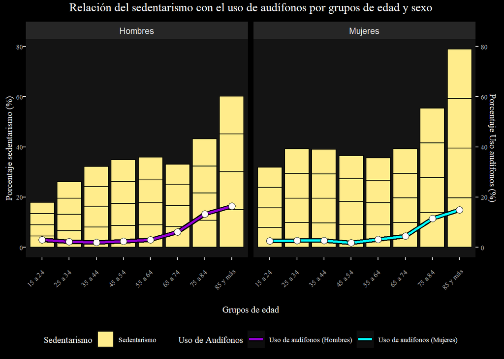

```r
grafico1_H <- grafico1 %>% filter(.data = ., Sexo == "Hombres")
grafico1_M <- grafico1 %>% filter(.data = ., Sexo == "Mujeres")

grafico1 %>%
  ggplot() +
  geom_col(aes(x = Edad, y = porcentaje_sedentarios/4, fill = "Sedentarismo"), color = "black") +
    scale_fill_manual(values = c("#FFEC8B")) +
  geom_borderline(data = grafico1_H, aes(x = Edad, y = porcentaje_audifonos, color = "Uso de audífonos (Hombres)"), linewidth = 1.2, bordercolor = "black", group = 1) +
  geom_borderline(data = grafico1_M, aes(x = Edad, y = porcentaje_audifonos, color = "Uso de audífonos (Mujeres)"), linewidth = 1.2, bordercolor = "black",group = 1) +
  scale_y_continuous(sec.axis = sec_axis(~., name = "Porcentaje Uso audífonos (%)")) +
  guides(x = guide_axis(angle =45)) +
  facet_wrap(facets = vars(Sexo), nrow = 1) +
  geom_point(data = grafico1_M, aes(x = Edad, y = porcentaje_audifonos), size=3, shape=21, fill="snow", color = "black") +
  geom_point(data = grafico1_H, aes(x = Edad, y = porcentaje_audifonos), size=3, shape=21, fill="snow", color = "black") +
  guides(fill = guide_legend(title = "Sedentarismo")) +
  guides(color = guide_legend(title = "Uso de Audífonos")) +
  labs(x= "Grupos de edad",
       y = "Porcentaje sedentarismo (%)",
       title = "Relación del sedentarismo con el uso de audífonos por grupos de edad y sexo") +
  dark_theme_gray() +
    theme (panel.grid.major = element_blank(), panel.grid.minor = element_blank(),
    plot.title =element_text(
        family = "serif",
        size = 12,
        hjust = 0.5,
        vjust = 2),
    axis.title = element_text(
                   family = "serif",
                   size = 9),
    axis.text = element_text(
                   family = "serif",
                   size = 7),
    axis.text.x = element_text(
                    margin=margin(8, b = 12)),
    axis.text.y = element_text(
                    margin=margin(8, b = 12))) + scale_color_manual(values = c("#9400D3", "cyan")) +
    theme(legend.title = element_text(
                    family = "serif",
                    size = 9),
        legend.text = element_text (
                    family = "serif",
                    size = 7),
        legend.position = "bottom")
```

1.- En este primer gráfico se han creado dos facetas en función del sexo de los individuos, donde se incluyen todos los grupos de edad. Los gráficos de barras se corresponden con el porcentaje de sedentarismo mientras que las líneas representan el porcentaje del uso de audífonos. Podemos observar cómo, tanto en el caso de los hombres con en el de las mujeres, el porcentaje de sedentarismo tiende a aumentar con la edad, al igual que sucede con el porcentaje de uso de audífonos, donde, si bien la línea no presenta una variación muy significativa entre los 15 y los 64 años de edad, aumenta considerablemente en grupos de edad mayores. A partir de lo expuesto, se puede inferir que la utilización de audífonos en función del porcentaje de sedentarismo sí que se ve afectado por el grupo de edad en el que se estudie el efecto descrito (a mayor grupo de edad, mayor sedentarismo y mayor uso de audífonos) Pese a ello, es complejo determinar si el incremento en el uso de audífonos extrapolado en consecuencia exclusiva del aumento del sedentarismo correlacionado con el grupo de edad o es debido a otros factores relacionados con la longevidad de las personas que no han sido objeto de estudio.

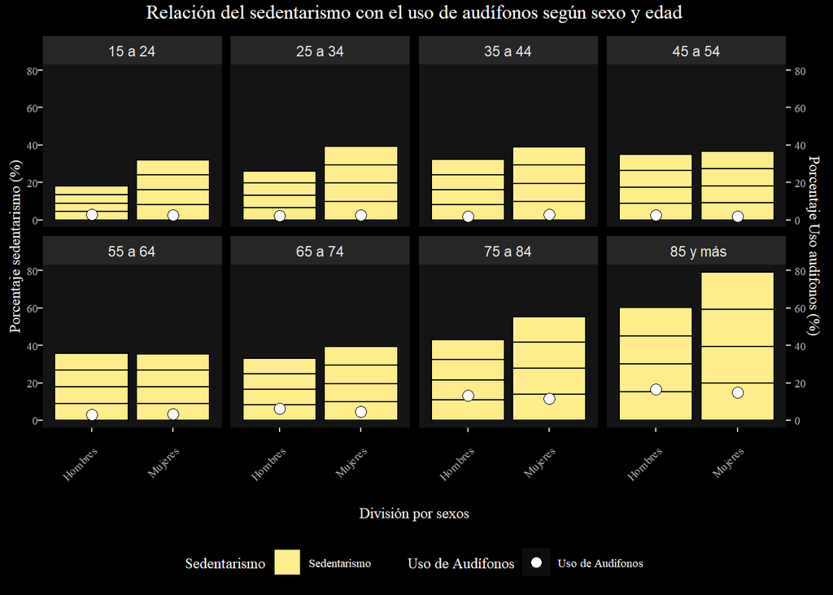

```r
grafico1 %>%
  ggplot() +
  geom_col(aes(x = Sexo, y = porcentaje_sedentarios/4, fill = "Sedentarismo"), color = "black") +
  scale_fill_manual(values = c("#FFEC8B")) +
  scale_y_continuous(sec.axis = sec_axis(~., name = "Porcentaje Uso audífonos (%)")) +
  guides(x = guide_axis(angle =45)) +
  guides(fill = guide_legend(title = "Sedentarismo")) +
  guides(shape = guide_legend(title = "Uso de Audífonos")) +
  facet_wrap(facets = vars(Edad), nrow = 2) +
  geom_point(data = grafico1, aes(x = Sexo, y = porcentaje_audifonos, shape = "Uso de Audifonos"), size=3, fill="snow", color = "black") +
  scale_shape_manual(values = c(21, 21)) +
  labs(x= "División por sexos",
       y = "Porcentaje sedentarismo (%)",
       title = "Relación del sedentarismo con el uso de audífonos según sexo y edad") +
  dark_theme_gray() +
    theme(panel.grid.major = element_blank(), panel.grid.minor = element_blank(),
    plot.title =element_text(
        family = "serif",
        size = 12,
        hjust = 0.5,
        vjust = 2),
    axis.title = element_text(
                   family = "serif",
                   size = 9),
    axis.text = element_text(
                   family = "serif",
                   size = 7),
    axis.text.x = element_text(
                    margin=margin(8, b = 12)),
    axis.text.y = element_text(
                    margin=margin(8, b = 12))) +
  theme(legend.title = element_text(
                      family = "serif",
                      size = 9),
        legend.text = element_text (
                      family = "serif",
                      size = 7),
        legend.position = "bottom")
```

2.- En este segundo gráfico, nuevamente, representamos los porcentajes de sedentarismo contra el uso de audífono en función de edad y sexo utilizando para ello facetas, solo que, para que, en este segundo gráfico, la información presente resulte más significativa y representativa, al menos en apariencia, para estudiar las diferencias en función del sexo, hacemos que las facetas se dividan a razón de los distintos grupos de edad. Podemos observar una tendencia relativa aparente a un mayor sedentarismo en las mujeres, mientras que, en contraposición, los varones utilizan porcentualmente mayor cantidad de audífonos. Se puede inferir por tanto que no existe una relación aparente entre un mayor porcentaje de sedentarismo y, en consecuencia, de uso de audífonos, en función del sexo de los individuos a estudio. Esto podría deberse a factores externos que no se han considerado en el desarrollo de este trabajo que favorezcan un mayor empleo de audífonos en los individuos varones.

```r
sedent_gafas <-
  gafas_SexAge %>%
  mutate(numero_gafas = Valor*1000) %>%
  select("Sexo", "Gafas", "numero_gafas", "Edad") %>%
  full_join(x = .,
            y = sedent_SexAge %>%
            mutate(personas_sedentarias = Valor*1000) %>%
            select("Sexo", "Sedentarismo", "personas_sedentarias", "Edad"),
            by = c("Sexo" = "Sexo", "Edad" = "Edad"))
```

```r
grafico2 <-sedent_gafas %>%
  filter(Sexo != "Ambos sexos") %>%
  filter(Gafas %in% c(" Sí", " No")) %>%
  filter(Sedentarismo %in% c(" Sí", " No")) %>%
  mutate(ratio_gafas_por_persona = 100*numero_gafas/personas_sedentarias) %>%
  filter(Edad!=" TOTAL")
```

```r
cont <- 1
sedentarios <- c(NA, NA, NA, NA, NA, NA, NA, NA)
no_sedentarios <- c(NA, NA, NA, NA, NA, NA, NA, NA)
aux <- 1
for (i in 1:(length(grafico2$personas_sedentarias)/4)){
si_sedent <- grafico2$personas_sedentarias[cont]
cont <- cont + 1
no_sedent <- grafico2$personas_sedentarias[cont]
cont <- cont + 3
sedentarios[aux] <- si_sedent
no_sedentarios[aux] <- no_sedent
aux <- aux + 1
}
```

```r
grafico2$porcentaje_sedentarios <- NA
grafico2$porcentaje_no_sedentarios <- NA

aux <- 1
for (i in 1:length(grafico2$porcentaje_sedentarios)){
grafico2$porcentaje_sedentarios[i] <- sedentarios[aux]*100/(sedentarios[aux] + no_sedentarios[aux])
grafico2$porcentaje_no_sedentarios[i] <- no_sedentarios[aux]*100/(sedentarios[aux] + no_sedentarios[aux])
if(i%%4 == 0){
aux <- aux + 1
}
}
```

```r
cont <- 1
gafas <- c(NA, NA, NA, NA, NA, NA, NA, NA)
no_gafas <- c(NA, NA, NA, NA, NA, NA, NA, NA)
aux <- 1
for (i in 1:(length(grafico2$numero_gafas)/4)){
gf <- grafico2$numero_gafas[cont]
cont <- cont + 2
no_gf <- grafico2$numero_gafas[cont]
cont <- cont + 2
gafas[aux] <- gf
no_gafas[aux] <- no_gf
aux <- aux + 1
}

grafico2$porcentaje_gafas <- NA
grafico2$porcentaje_no_gafas <- NA

aux <- 1
for (i in 1:length(grafico2$numero_gafas)){
grafico2$porcentaje_gafas[i] <- gafas[aux]*100/(gafas[aux] + no_gafas[aux])
grafico2$porcentaje_no_gafas[i] <- no_gafas[aux]*100/(gafas[aux] + no_gafas[aux])
if(i%%4 == 0){
aux <- aux + 1
}
}
```

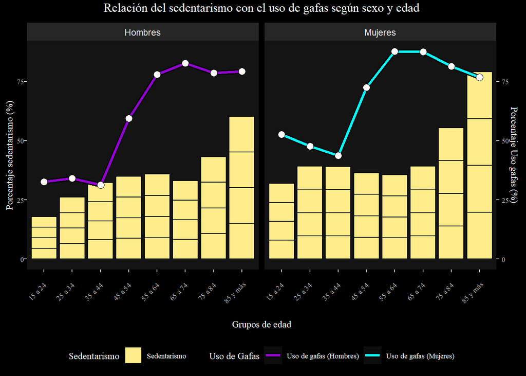

```r
grafico2_H <- grafico2 %>% filter(.data = ., Sexo == "Hombres")
grafico2_M <- grafico2 %>% filter(.data = ., Sexo == "Mujeres")

grafico2 %>%
  ggplot() +
  geom_col(aes(x = Edad, y = porcentaje_sedentarios/4, fill = "Sedentarismo"), color = "black") +
  scale_fill_manual(values = c("#FFEC8B")) +
  geom_borderline(data = grafico2_H, aes(x = Edad, y = porcentaje_gafas, color = "Uso de gafas (Hombres)"), linewidth = 1.2, bordercolor = "black", group = 1) +
  geom_borderline(data = grafico2_M, aes(x = Edad, y = porcentaje_gafas, color = "Uso de gafas (Mujeres)"), linewidth = 1.2, bordercolor = "black",group = 1) +
  scale_y_continuous(sec.axis = sec_axis(~., name = "Porcentaje Uso gafas (%)")) +
  guides(x = guide_axis(angle =45)) +
  guides(fill = guide_legend(title = "Sedentarismo")) +
  guides(color = guide_legend(title = "Uso de Gafas")) +
  facet_wrap(facets = vars(Sexo), nrow = 1) +
  geom_point(data = grafico2_M, aes(x = Edad, y = porcentaje_gafas), size=3, shape=21, fill="snow", color = "black") +
  geom_point(data = grafico2_H, aes(x = Edad, y = porcentaje_gafas), size=3, shape=21, fill="snow", color = "black") +
  labs(x= "Grupos de edad",
       y = "Porcentaje sedentarismo (%)",
       title = "Relación del sedentarismo con el uso de gafas según sexo y edad") +
  dark_theme_gray() +
    theme(panel.grid.major = element_blank(), panel.grid.minor = element_blank(),
    plot.title =element_text(
        family = "serif",
        size = 12,
        hjust = 0.5,
        vjust = 2),
    axis.title = element_text(
                   family = "serif",
                   size = 9),

    axis.text = element_text(
                   family = "serif",
                   size = 7),

    axis.text.x = element_text(
                    margin=margin(8, b = 12)),
    axis.text.y = element_text(
                    margin=margin(8, b = 12))) + scale_color_manual(values = c("#9400D3", "cyan")) +
  theme(legend.title = element_text(
                      family = "serif",
                      size = 9),
        legend.text = element_text (
                      family = "serif",
                      size = 7),
        legend.position = "bottom")
```

3.- En este tercer gráfico, del mismo modo que en el primero de los gráficos mostrados, se han creado dos facetas en función del sexo de los individuos, donde se incluyen todos los grupos de edad. Los gráficos de barras se corresponden, de nuevo, con el porcentaje de sedentarismo, mientras que, en este caso, las líneas representan el porcentaje de uso de gafas. Podemos observar cómo no parece existir una relación directa extrapolable entre el porcentaje de sedentarismo y la utilización de gafas en función del grupo de edad, ya que alcanza máximos en valores relativamente bajos de porcentaje de sedentarismo según grupo de edad y no en los valores igualmente máximos de dicha cualidad estudiada.

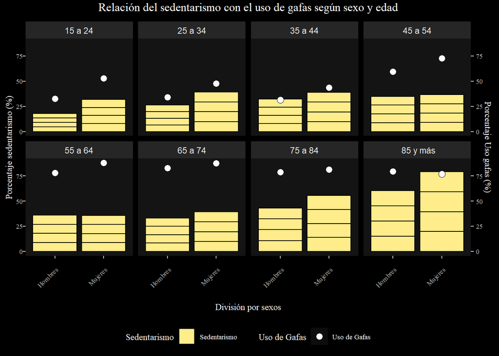

```r
grafico2 %>%
  ggplot() +
  geom_col(aes(x = Sexo, y = porcentaje_sedentarios/4, fill = "Sedentarismo"), color = "black") +
  scale_fill_manual(values = c("#FFEC8B")) +
  scale_y_continuous(sec.axis = sec_axis(~., name = "Porcentaje Uso gafas (%)")) +
  guides(x = guide_axis(angle =45)) +
  guides(fill = guide_legend(title = "Sedentarismo")) +
  guides(shape = guide_legend(title = "Uso de Gafas")) +
  facet_wrap(facets = vars(Edad), nrow = 2) +
  geom_point(data = grafico2, aes(x = Sexo, y = porcentaje_gafas, shape = "Uso de Gafas"), size=3, fill="snow", color = "black") +
  scale_shape_manual(values = c(21, 21)) +
  labs(x= "División por sexos",
       y = "Porcentaje sedentarismo (%)",
       title = "Relación del sedentarismo con el uso de gafas según sexo y edad") +
  dark_theme_gray() +
    theme(panel.grid.major = element_blank(), panel.grid.minor = element_blank(),
    plot.title =element_text(
        family = "serif",
        size = 12,
        hjust = 0.5,
        vjust = 2),
    axis.title = element_text(
                   family = "serif",
                   size = 9),
    axis.text = element_text(
                   family = "serif",
                   size = 7),
    axis.text.x = element_text(
                    margin=margin(8, b = 12)),
    axis.text.y = element_text(
                    margin=margin(8, b = 12))) +
  theme(legend.title = element_text(
                      family = "serif",
                      size = 9),
        legend.text = element_text (
                      family = "serif",
                      size = 7),
        legend.position = "bottom")
```

4.- En este cuarto gráfico, de forma análoga al segundo gráfico mostrado, se han representado los porcentajes de sedentarismo contra el uso de gafas en función de la edad y el sexo utilizados para ello un total de 8 facetas, de forma que la información resulte más significativa y representativa para estudiar las diferencias en función del sexo, de modo que dividimos los datos en facetas a razón de los 8 grupos de edad. En contraste al caso del uso de audífonos, podemos apreciar cómo, del mismo modo que los porcentajes de mujeres sedentarias presenta unos valores más elevados que los porcentajes de varones sedentarios, los porcentajes de uso de gafas también son, a nivel general, mayores en mujeres que en hombres. De este modo y, a partir de este gráfico y el anterior, podría inferirse que existe una relación aparente entre un mayor porcentaje de sedentarismo y, en consecuencia, de uso de gafas, en función del sexo de los individuos estudiados.

## CONCLUSIONES

En conclusión, parece existir cierta garantía acerca del hecho de que sí que existe cierta relación entre tener un estilo de vida sedentario y padecer un mayor riesgo a problemas en la visión y/o en la audición (si bien no tenemos información directa de estas características puede ser fácilmente extrapolada con seguridad de la información sobre uso de gafas y/o audífonos, respectivamente). Como se ha ido indicando, el estudio realizado ha encontrado resultados aparentes más significativos en lo que respecta a uso de audífonos en función del grupo de edad, mientras que, en función del sexo, los resultados parecen arrojar más luz para el uso de gafas. En definitiva, las conclusiones no se pueden considerar sólidas certezas, pero pensamos que sí que siembran la semilla para futuros estudios sobre la relación poco estudiada y, aparentemente, existente, entre uso de gafas y/o audífonos como indicativo directo de enfermedad visuales y/o auditivas; y el estilo de vida sedentario de las poblaciones.

## BIBLIOGRAFÍA 📖

[1] Rodulfo, J. I. A. (2019). Sedentarism, a disease from XXI century. Clínica e Investigación en arteriosclerosis (English edition), 31(5), 233-240. https://doi.org/10.1016/j.artere.2019.04.001

[2] Hu, F. B. (2003). Sedentary lifestyle and risk of obesity and type 2 diabetes. Lipids, 38(2), 103-108.

```r
citation()
```

```
##
##   R Core Team (2023). _R: A Language and Environment for Statistical
##   Computing_. R Foundation for Statistical Computing, Vienna, Austria.
##   <https://www.R-project.org/>.
##
## A BibTeX entry for LaTeX users is
##
##   @Manual{,
##     title = {R: A Language and Environment for Statistical Computing},
##     author = {{R Core Team}},
##     organization = {R Foundation for Statistical Computing},
##     address = {Vienna, Austria},
##     year = {2023},
##     url = {https://www.R-project.org/},
##   }
##
## We have invested a lot of time and effort in creating R, please cite it
## when using it for data analysis. See also 'citation("pkgname")' for
## citing R packages.
```

[3] R Core Team (2023). *R: A Language and Environment for Statistical Computing*. R Foundation for Statistical Computing, Vienna, Austria. https://www.R-project.org/.

```r
citation("tidyjson")
```

```
##
##   Stanley J, Arendt C (2023). _tidyjson: Tidy Complex 'JSON'_. R
##   package version 0.3.2, <https://CRAN.R-project.org/package=tidyjson>.
##
## A BibTeX entry for LaTeX users is
##
##   @Manual{,
##     title = {tidyjson: Tidy Complex 'JSON'},
##     author = {Jeremy Stanley and Cole Arendt},
##     year = {2023},
##     note = {R package version 0.3.2},
##     url = {https://CRAN.R-project.org/package=tidyjson},
##   }
```

[4] Stanley J, Arendt C (2023). *tidyjson: Tidy Complex ‘JSON’*. R package version 0.3.2, https://CRAN.R-project.org/package=tidyjson.

```r
citation("rjson")
```

```
##
##   Couture-Beil A (2022). _rjson: JSON for R_. R package version 0.2.21,
##   <https://CRAN.R-project.org/package=rjson>.
##
## A BibTeX entry for LaTeX users is
##
##   @Manual{,
##     title = {rjson: JSON for R},
##     author = {Alex Couture-Beil},
##     year = {2022},
##     note = {R package version 0.2.21},
##     url = {https://CRAN.R-project.org/package=rjson},
##   }
##
## ATTENTION: This citation information has been auto-generated from the
## package DESCRIPTION file and may need manual editing, see
## 'help("citation")'.
```

[5] Couture-Beil A (2022). *rjson: JSON for R*. R package version 0.2.21, https://CRAN.R-project.org/package=rjson.

```r
citation("tidyverse")
```

```
##
##   Wickham H, Averick M, Bryan J, Chang W, McGowan LD, François R,
##   Grolemund G, Hayes A, Henry L, Hester J, Kuhn M, Pedersen TL, Miller
##   E, Bache SM, Müller K, Ooms J, Robinson D, Seidel DP, Spinu V,
##   Takahashi K, Vaughan D, Wilke C, Woo K, Yutani H (2019). "Welcome to
##   the tidyverse." _Journal of Open Source Software_, *4*(43), 1686.
##   doi:10.21105/joss.01686 <https://doi.org/10.21105/joss.01686>.
##
## A BibTeX entry for LaTeX users is
##
##   @Article{,
##     title = {Welcome to the {tidyverse}},
##     author = {Hadley Wickham and Mara Averick and Jennifer Bryan and Winston Chang and Lucy D'Agostino McGowan and Romain François and Garrett Grolemund and Alex Hayes and Lionel Henry and Jim Hester and Max Kuhn and Thomas Lin Pedersen and Evan Miller and Stephan Milton Bache and Kirill Müller a…
##     year = {2019},
##     journal = {Journal of Open Source Software},
##     volume = {4},
##     number = {43},
##     pages = {1686},
##     doi = {10.21105/joss.01686},
##   }
```

[6] Wickham H, Averick M, Bryan J, Chang W, McGowan LD, François R, Grolemund G, Hayes A, Henry L, Hester J, Kuhn M, Pedersen TL, Miller E, Bache SM, Müller K, Ooms J, Robinson D, Seidel DP, Spinu V, Takahashi K, Vaughan D, Wilke C, Woo K, Yutani H (2019). “Welcome to the tidyverse.” *Journal of Open Source Software*, *4*(43), 1686. doi:10.21105/joss.01686 https://doi.org/10.21105/joss.01686.

```r
citation("readr")
```

```
##
##   Wickham H, Hester J, Bryan J (2023). _readr: Read Rectangular Text
##   Data_. R package version 2.1.4,
##   <https://CRAN.R-project.org/package=readr>.
##
## A BibTeX entry for LaTeX users is
##
##   @Manual{,
##     title = {readr: Read Rectangular Text Data},
##     author = {Hadley Wickham and Jim Hester and Jennifer Bryan},
##     year = {2023},
##     note = {R package version 2.1.4},
##     url = {https://CRAN.R-project.org/package=readr},
##   }
```

[7] Wickham H, Hester J, Bryan J (2023). *readr: Read Rectangular Text Data*. R package version 2.1.4, https://CRAN.R-project.org/package=readr.

```r
citation("readxl")
```

```
##
##   Wickham H, Bryan J (2023). _readxl: Read Excel Files_. R package
##   version 1.4.3, <https://CRAN.R-project.org/package=readxl>.
##
## A BibTeX entry for LaTeX users is
##
##   @Manual{,
##     title = {readxl: Read Excel Files},
##     author = {Hadley Wickham and Jennifer Bryan},
##     year = {2023},
##     note = {R package version 1.4.3},
##     url = {https://CRAN.R-project.org/package=readxl},
##   }
```

[8] Wickham H, Bryan J (2023). *readxl: Read Excel Files*. R package version 1.4.3, https://CRAN.R-project.org/package=readxl.

```r
citation("dplyr")
```

```
##
##   Wickham H, François R, Henry L, Müller K, Vaughan D (2023). _dplyr: A
##   Grammar of Data Manipulation_. R package version 1.1.3,
##   <https://CRAN.R-project.org/package=dplyr>.
##
## A BibTeX entry for LaTeX users is
##
##   @Manual{,
##     title = {dplyr: A Grammar of Data Manipulation},
##     author = {Hadley Wickham and Romain François and Lionel Henry and Kirill Müller and Davis Vaughan},
##     year = {2023},
##     note = {R package version 1.1.3},
##     url = {https://CRAN.R-project.org/package=dplyr},
##   }
```

[9] Wickham H, François R, Henry L, Müller K, Vaughan D (2023). *dplyr: A Grammar of Data Manipulation*. R package version 1.1.3, https://CRAN.R-project.org/package=dplyr.

```r
citation("ggplot2")
```

```
##
##   H. Wickham. ggplot2: Elegant Graphics for Data Analysis.
##   Springer-Verlag New York, 2016.
##
## A BibTeX entry for LaTeX users is
##
##   @Book{,
##     author = {Hadley Wickham},
##     title = {ggplot2: Elegant Graphics for Data Analysis},
##     publisher = {Springer-Verlag New York},
##     year = {2016},
##     isbn = {978-3-319-24277-4},
##     url = {https://ggplot2.tidyverse.org},
##   }
```

[10] H. Wickham. ggplot2: Elegant Graphics for Data Analysis. Springer-Verlag New York, 2016.

```r
citation("tidyr")
```

```
##
##   Wickham H, Vaughan D, Girlich M (2023). _tidyr: Tidy Messy Data_. R
##   package version 1.3.0, <https://CRAN.R-project.org/package=tidyr>.
##
## A BibTeX entry for LaTeX users is
##
##   @Manual{,
##     title = {tidyr: Tidy Messy Data},
##     author = {Hadley Wickham and Davis Vaughan and Maximilian Girlich},
##     year = {2023},
##     note = {R package version 1.3.0},
##     url = {https://CRAN.R-project.org/package=tidyr},
##   }
```

[11] Wickham H, Vaughan D, Girlich M (2023). *tidyr: Tidy Messy Data*. R package version 1.3.0, https://CRAN.R-project.org/package=tidyr.

```r
citation("ggborderline")
```

```
##
##   Scott J (2022). _ggborderline: Line Plots that Pop_. R package
##   version 0.2.0, <https://CRAN.R-project.org/package=ggborderline>.
##
## A BibTeX entry for LaTeX users is
##
##   @Manual{,
##     title = {ggborderline: Line Plots that Pop},
##     author = {Jacob Scott},
##     year = {2022},
##     note = {R package version 0.2.0},
##     url = {https://CRAN.R-project.org/package=ggborderline},
##   }
##
## ATTENTION: This citation information has been auto-generated from the
## package DESCRIPTION file and may need manual editing, see
## 'help("citation")'.
```

[12] Scott J (2022). *ggborderline: Line Plots that Pop*. R package version 0.2.0, https://CRAN.R-project.org/package=ggborderline.

```r
citation("ggdark")
```

```
##
##   Grantham N (2019). _ggdark: Dark Mode for 'ggplot2' Themes_. R
##   package version 0.2.1, <https://CRAN.R-project.org/package=ggdark>.
##
## A BibTeX entry for LaTeX users is
##
##   @Manual{,
##     title = {ggdark: Dark Mode for 'ggplot2' Themes},
##     author = {Neal Grantham},
##     year = {2019},
##     note = {R package version 0.2.1},
##     url = {https://CRAN.R-project.org/package=ggdark},
##   }
##
## ATTENTION: This citation information has been auto-generated from the
## package DESCRIPTION file and may need manual editing, see
## 'help("citation")'.
```

[13] Grantham N (2019). *ggdark: Dark Mode for ‘ggplot2’ Themes*. R package version 0.2.1, https://CRAN.R-project.org/package=ggdark.